# Hidden neighbourhood effects may introduce confounding in regression models

Joseph Bulbulia https://josephbulbulia.netlify.app (Victoria University of Wellington)https://www.wgtn.ac.nz  
2021-MAY-20

```r
# Set up

# packages
# install_rethinking
# function for installing dependencies
# ipak <- function(pkg){
# new.pkg <- pkg[!(pkg %in% installed.packages()[, "Package"])]
# if (length(new.pkg))
#     install.packages(new.pkg, dependencies = TRUE)
# sapply(pkg, require, character.only = TRUE)
# }
# # usage
# packages <- c("coda", "plyr", "mvtnorm", "scales", "dagitty")
# ipak(packages)
# next install rethinking
if (!require(rethinking)) {
  devtools::install_github("rmcelreath/rethinking")
}
#next install ggdag
if (!require(ggdag)) {
  devtools::install_github("malcolmbarrett/ggdag")
}


# libraries
library("tidyverse")
library("ggdag")
library("brms")
library("rstan")
library("rstanarm")
library("tidybayes")
library("bayesplot")
library("easystats")
# rstan options
rstan_options(auto_write=TRUE)
options(mc.cores=parallel::detectCores ())
theme_set(theme_classic())
```

```r
# options
knitr::opts_chunk$set(
  echo = TRUE,
  warning = FALSE,
  message = FALSE,
  layout = "l-body-outset",
  fig.width = 12,
  fig.height = 10,
  collapse = TRUE,
  R.options = list(width = 60)
)
```

Imagine a word in which we have the following relationships:

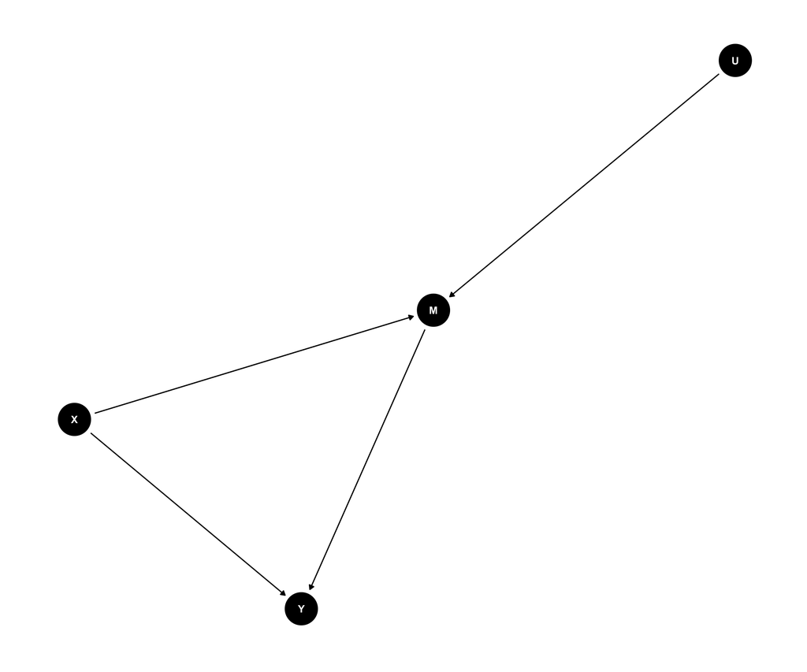

```r
library(ggdag)
# code for creating a DAG
ggdag_ov <- dagify(Y ~ X + M,
                   M ~ X + U,
                   exposure = "X",
                   outcome = "Y") %>%
  control_for("M")

# plot the DAG
ggdag_ov %>%
  ggdag() + theme_dag_blank()
```

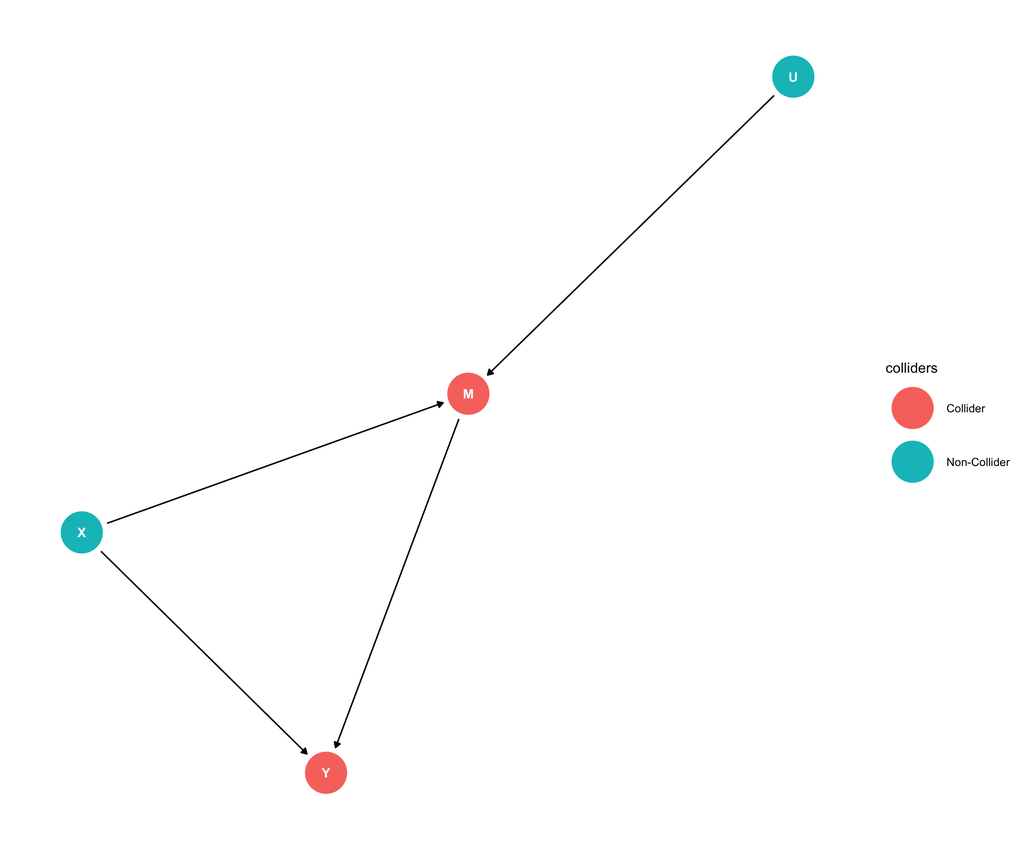

```r
# find colliders
ggdag::ggdag_collider( ggdag_ov )  + theme_dag_blank()
```

Because of this, neighbourhood effects can lead to confounding, making it appear as though the effect of X on Y is negative when we condition on M.

We can write a mediation model that does not adjust for neighbourhood effects (U), imagining these neighbourhood effects are unmeasured (as in our current dataset).

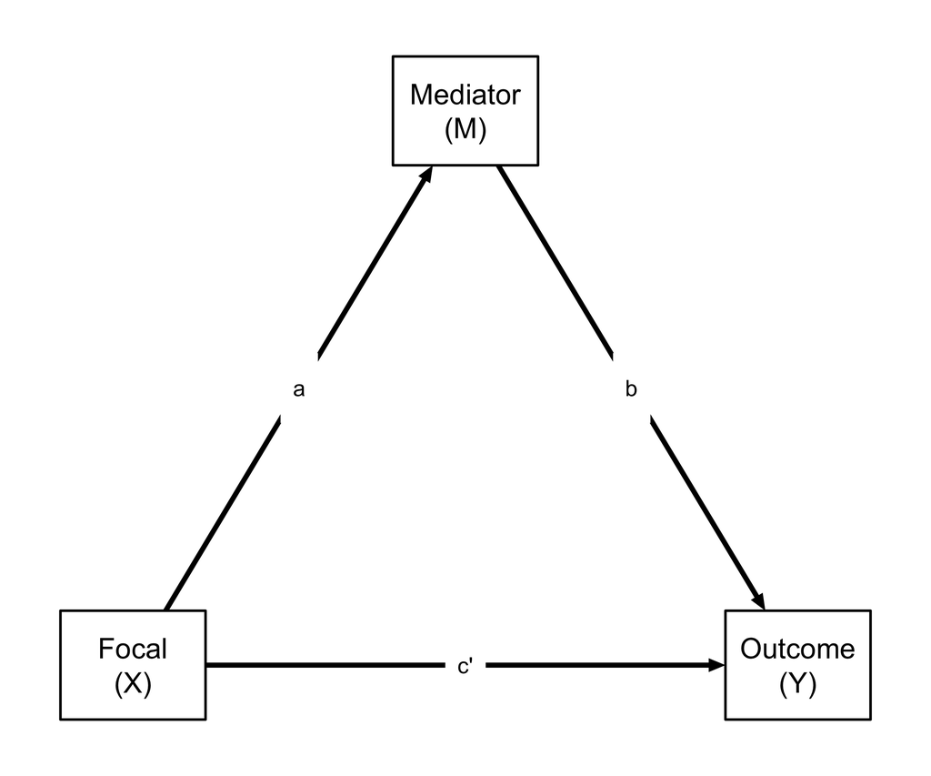

```r
bmlm::mlm_path_plot(xlab = "Focal\n(X)",
              mlab = "Mediator\n(M)",
              ylab = "Outcome\n(Y)")
```

```r
path_m <- brms::bf(M ~ X)
path_y <- brms::bf(Y ~ X + M)

m1 <- brms::brm(
  path_m + path_y + set_rescor(FALSE),
  data = d,
  file = here::here("models", "mediation-confound-simulation")
)

# output
# parameters::model_parameters(m1)
```

For the mediation model we recover the indirect, direct and total effects as follow:

```r
# get posterior distributions
post <- brms::posterior_samples(m1)

# sum and multiply the posterior distributions to obtain parameter estimates
post2 <- post %>%
  dplyr::transmute(
    a = b_M_X,
    b = b_Y_M,
    cp = b_Y_X,
    me = a * b,
    c = cp + me#,
    # pme = me / c
  )
```

The direct effect (cp) **appears to be negative!**

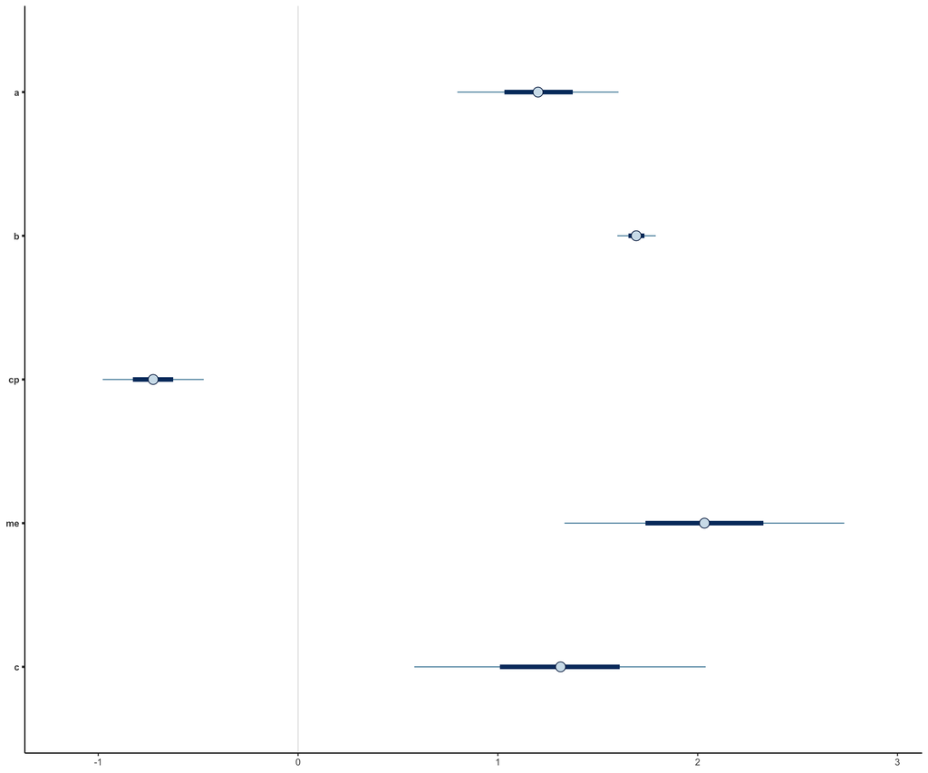

```r
# plot the results
mcmc_intervals(post2)
```

But recall, we simulated a direct effect coefficient of 0. This seemingly negative effect of X on Y is the result of conditioning on a collider, which opens a path between X and U.

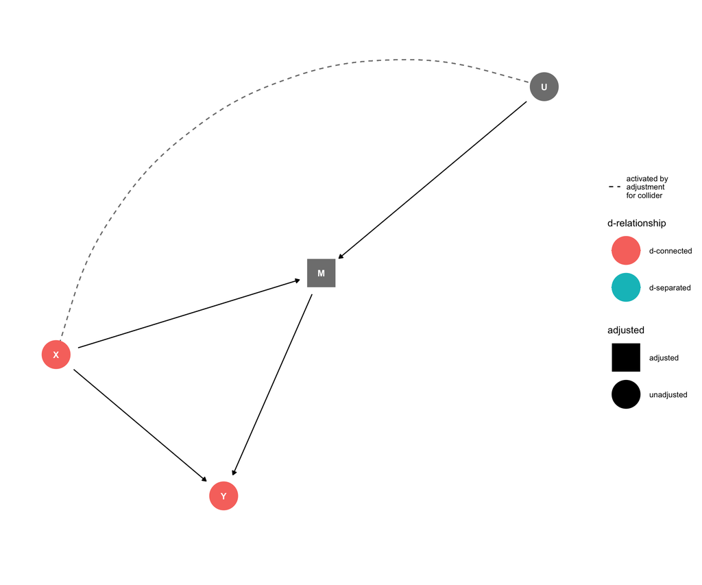

```r
ggdag::ggdag_dseparated(ggdag_ov, controlling_for = "M", collider_lines = TRUE )  + theme_dag_blank()
```

## Causal inference when we include neighbourhood effects.

This time, let’s included the previously un-modelled effect of neighbourhoods.

```r
path_m <- brms::bf(M ~ X )
path_y <- brms::bf(Y ~ X + M + U)

m2 <- brms::brm(
  path_m + path_y + set_rescor(FALSE),
  data = d,
  file = here::here("models", "mediation-confound-simulation-2")
)

# output
# parameters::model_parameters(m2)
```

Graphing results in a model that adjusts for neighbourhoods effects we correct for the confounding

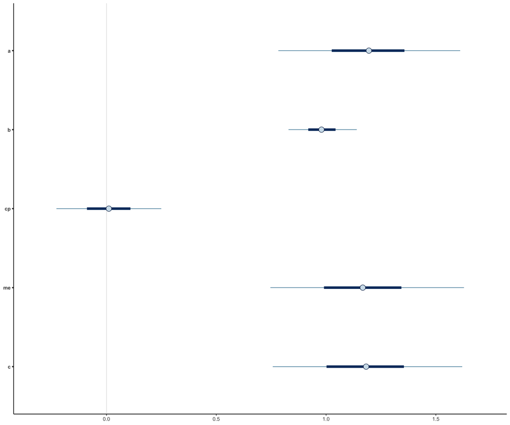

```r
# get posterior distributions
post2 <- brms::posterior_samples(m2)

# sum and multiply the posterior distributions to obtain parameter estimates
post2.2 <- post2 %>%
  dplyr::transmute(
    a = b_M_X,
    b = b_Y_M,
    cp = b_Y_X,
    me = a * b,
    c = cp + me#,
    # pme = me / c
  )

# plot the results
mcmc_intervals(post2.2)
```

That is, we recover the simulated direct effect (namely 0)

In short, if we are modelling relationships in which covariates are affected by neighbourhood effects, we might confound our results.

## Simple causal effects

The goods news is that for models in which we are only interested in the total effect of X on Y, it is sufficient for us to condition only X. (All backdoor paths are closed)

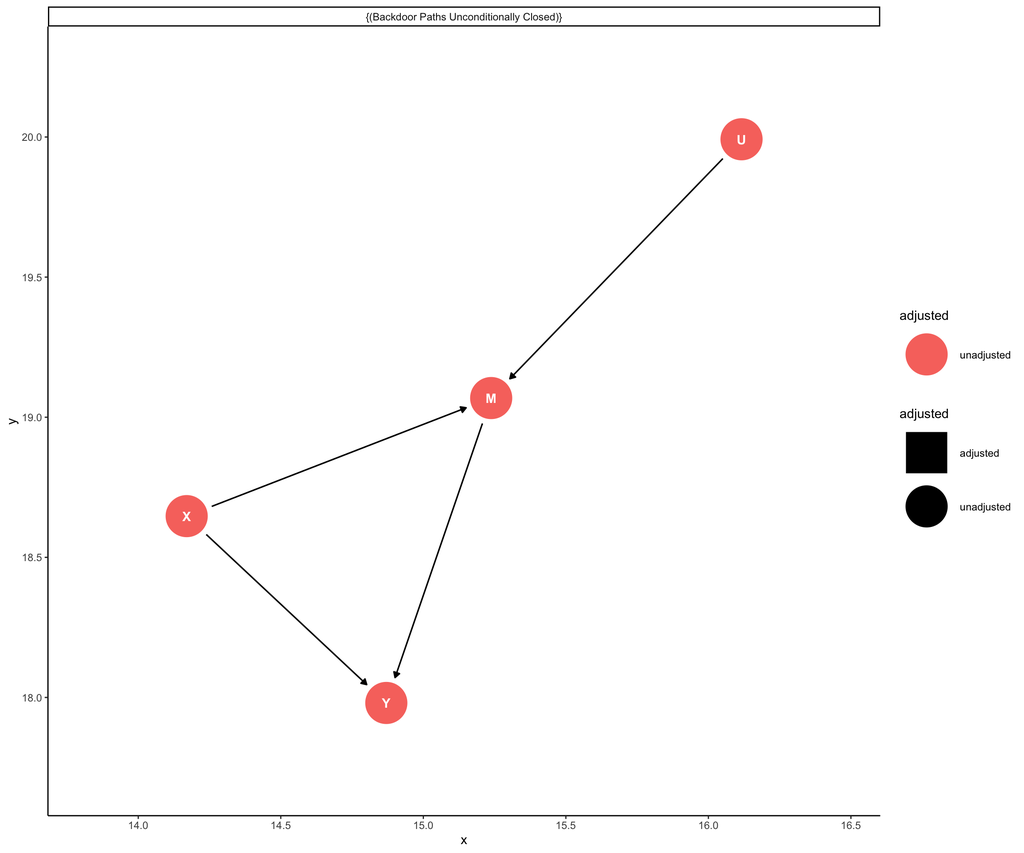

```r
# code for creating a DAG
ggdag_ov2 <- dagify(Y ~ X + M,
                   M ~ X + U,
                   exposure = "X",
                   outcome = "Y")

ggdag::ggdag_adjustment_set(ggdag_ov2)
```

Doing so gives us X’s total effect, which arises through X’s effect on M.

```r
par <- lm( Y ~ X, data = d)

tab_par <- parameters::model_parameters(par)

tab_par
```

```
Parameter   | Coefficient |   SE |        95% CI | t(98) |     p
----------------------------------------------------------------
(Intercept) |       -0.03 | 0.40 | [-0.83, 0.77] | -0.08 | 0.937
X           |        1.30 | 0.43 | [ 0.44, 2.16] |  3.01 | 0.003
```

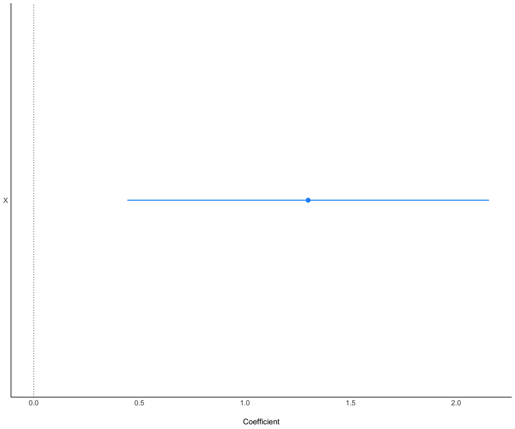

```r
tab_par %>%
  plot()
```

However, in such a model, the mechanism for the total effect of X on Y would remain obscure. And we should not be misled into thinking that X directly causes Y, even if this model contains no other covariates.